# Deliverable 4

Lana R

2026-10-27

```
## Rows: 8,500
## Columns: 18
## $ user_id                  <chr> "USR-00001", "USR-00002", "USR-00003", "USR-0…
## $ age                      <dbl> 29, 58, 41, 36, 23, 23, 20, 49, 36, 40, 18, 6…
## $ gender                   <chr> "Female", "Female", "Female", "Non-Binary", "…
## $ occupation_type          <chr> "Healthcare / Shift Worker", "Student", "Heal…
## $ chronotype               <chr> "Intermediate", "Intermediate", "Night Owl", …
## $ bedtime_phone_minutes    <dbl> 179, 163, 100, 34, 27, 76, 53, 113, 65, 70, 2…
## $ primary_bedtime_app      <chr> "Instagram / Reddit", "YouTube", "TikTok / Re…
## $ screen_brightness_pct    <dbl> 54, 76, 59, 52, 82, 39, 32, 34, 35, 63, 49, 7…
## $ blue_light_filter_active <dbl> 1, 1, 0, 0, 1, 0, 0, 1, 1, 1, 0, 1, 1, 1, 1, …
## $ caffeine_post_5pm_mg     <dbl> 0, 92, 45, 97, 0, 136, 0, 39, 0, 115, 0, 91, …
## $ physical_activity_min    <dbl> 21, 72, 23, 49, 38, 42, 64, 58, 25, 59, 34, 7…
## $ sleep_latency_min        <dbl> 84.4, 86.7, 70.5, 38.1, 32.3, 50.6, 36.2, 60.…
## $ total_sleep_hours        <dbl> 3.20, 4.06, 3.20, 6.99, 4.58, 5.87, 4.43, 5.9…
## $ deep_sleep_pct           <dbl> 23.5, 18.0, 18.1, 21.6, 24.1, 21.4, 22.7, 19.…
## $ rem_sleep_pct            <dbl> 22.2, 21.5, 20.5, 22.4, 22.8, 17.5, 19.0, 19.…
## $ morning_alarm_snoozes    <dbl> 7, 7, 7, 1, 4, 4, 6, 3, 1, 4, 2, 4, 2, 1, 0, …
## $ next_day_fatigue_score   <dbl> 10.0, 10.0, 10.0, 1.7, 5.3, 5.0, 6.4, 4.5, 1.…
## $ sleep_debt_category      <chr> "Severe Sleep Debt", "Severe Sleep Debt", "Se…
```

```
## [1] 8500   18
```

Data Dictionary

| Variable | Description | Type |
| --- | --- | --- |
| user_id | Unique participant ID | Identifier (categorical) |
| age | Age in years | Numerical |
| gender | Gender (Female, Male, Non-Binary) | Categorical |
| occupation_type | Type of job or occupation | Categorical |
| chronotype | Natural sleep preference (Morning Lark, Intermediate, Night Owl) | Categorical |
| bedtime_phone_minutes | Minutes spent on the phone in bed before sleeping | Numerical |
| primary_bedtime_app | App or content type used most at bedtime | Categorical |
| screen_brightness_pct | Phone screen brightness at bedtime (%) | Numerical |
| blue_light_filter_active | Whether a blue light filter was on (1 = yes, 0 = no) | Categorical (binary) |
| caffeine_post_5pm_mg | Caffeine consumed after 5 PM (mg) | Numerical |
| physical_activity_min | Minutes of physical activity | Numerical |
| sleep_latency_min | Minutes it took to fall asleep | Numerical |
| total_sleep_hours | Total hours of sleep | Numerical |
| deep_sleep_pct | Percent of sleep spent in deep sleep | Numerical |
| rem_sleep_pct | Percent of sleep spent in REM sleep | Numerical |
| morning_alarm_snoozes | Number of times the morning alarm was snoozed | Numerical (count) |
| next_day_fatigue_score | Fatigue felt the next day (1 = low, 10 = high) | Numerical |
| sleep_debt_category | Sleep debt level (Optimal Recovery, Mild Deficit, Moderate Debt, Severe Sleep Debt) | Categorical (ordered) |

```
##       user_id          age               gender
##  Length   :8500   Min.   :18.00   Female    :4347
##  N.unique :8500   1st Qu.:25.00   Male      :3905
##  N.blank  :   0   Median :32.00   Non-Binary: 248
##  Min.nchar:   9   Mean   :34.36
##  Max.nchar:   9   3rd Qu.:42.00
##                   Max.   :65.00
##                   occupation_type        chronotype   bedtime_phone_minutes
##  Corporate 9-to-5         :2838   Morning Lark:2165   Min.   :  1.00
##  Freelance / Creative     : 901   Intermediate:3880   1st Qu.: 31.00
##  Healthcare / Shift Worker: 997   Night Owl   :2455   Median : 51.00
##  Remote Tech              :2142                       Mean   : 59.25
##  Student                  :1622                       3rd Qu.: 79.00
##                                                       Max.   :180.00
##                primary_bedtime_app screen_brightness_pct
##  Instagram / Reddit      :1630     Min.   : 10.00
##  Messaging / Chat        : 847     1st Qu.: 42.00
##  News / Reading          : 596     Median : 55.00
##  Streaming (Netflix/Hulu):1301     Mean   : 55.15
##  TikTok / Reels          :2198     3rd Qu.: 69.00
##  YouTube                 :1928     Max.   :100.00
##  blue_light_filter_active caffeine_post_5pm_mg physical_activity_min
##  Off:4524                 Min.   :  0.00       Min.   :  0.0
##  On :3976                 1st Qu.:  0.00       1st Qu.: 21.0
##                           Median :  0.00       Median : 35.0
##                           Mean   : 33.22       Mean   : 35.7
##                           3rd Qu.: 55.00       3rd Qu.: 50.0
##                           Max.   :250.00       Max.   :112.0
##  sleep_latency_min total_sleep_hours deep_sleep_pct  rem_sleep_pct
##  Min.   :  6.00    Min.   :3.200     Min.   : 8.10   Min.   : 9.60
##  1st Qu.: 28.20    1st Qu.:5.240     1st Qu.:19.70   1st Qu.:17.40
##  Median : 37.60    Median :6.330     Median :21.90   Median :19.10
##  Mean   : 40.67    Mean   :6.266     Mean   :21.74   Mean   :19.11
##  3rd Qu.: 49.70    3rd Qu.:7.350     3rd Qu.:23.90   3rd Qu.:20.80
##  Max.   :123.30    Max.   :9.800     Max.   :28.00   Max.   :27.00
##  morning_alarm_snoozes next_day_fatigue_score        sleep_debt_category
##  Min.   :0.000         Min.   : 1.000         Optimal Recovery :1387
##  1st Qu.:2.000         1st Qu.: 1.100         Mild Deficit     :2004
##  Median :3.000         Median : 3.200         Moderate Debt    :4462
##  Mean   :2.766         Mean   : 3.795         Severe Sleep Debt: 647
##  3rd Qu.:4.000         3rd Qu.: 5.600
##  Max.   :7.000         Max.   :10.000
```

### Changes after Deliverable 3

Added the color theme code and the first 4 ggplots presented after this with their descriptions. Changed the descriptions of all the ggplots to match the first 4. Added the overall take to the end of the doc.

### Summary Statistics

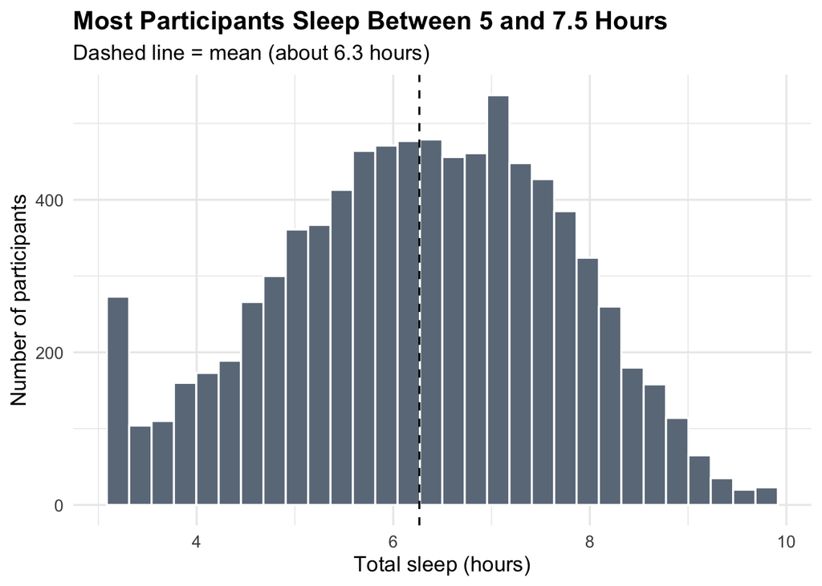

##### This histogram shows how many participants fall at each level of nightly sleep, using total_sleep_hours. The distribution is roughly bell-shaped, centered near 6.3 hours (median about 6.3, middle 50% between about 5.2 and 7.4), with values from 3.2 to 9.8 hours. This suggests the typical participant sleeps less than the commonly recommended 7 to 9 hours, with about 42% under 6 hours. One possible explanation is that this histogram blends several different groups together, such as people with different sleep preferences or jobs. I would check this next by splitting the distribution by group, which is what Visualization 2 does (figure below).

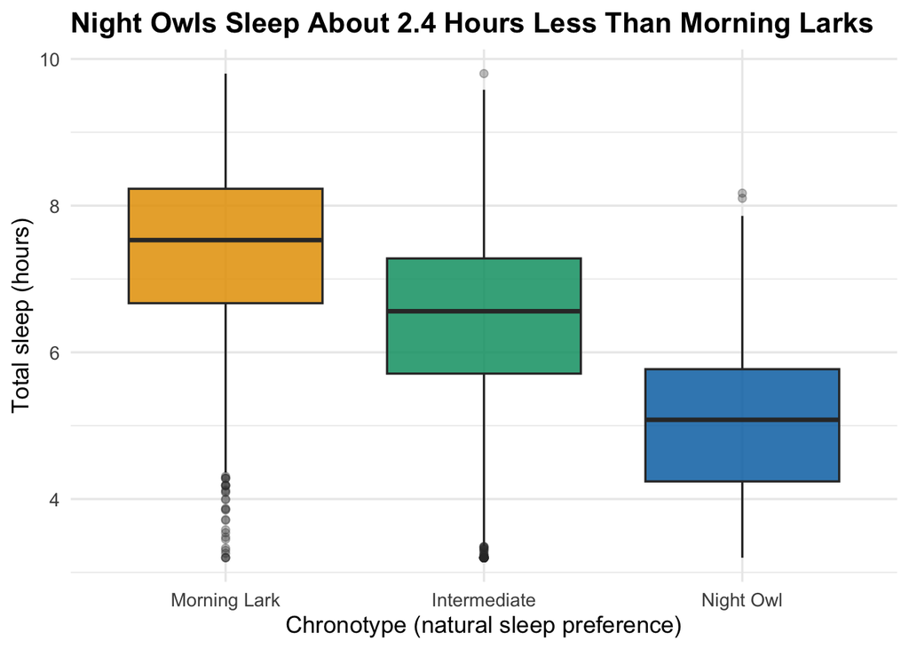

##### This box plot compares total_sleep_hours across the three chronotype groups, with the box showing the middle 50% of people and the line showing the median. Morning Larks have the highest sleep (median about 7.5 hours), Intermediate is in the middle (about 6.6), and Night Owls are far lower (about 5.1, with their middle 50% between about 4.2 and 5.8). This suggests that sleep preference is strongly linked to how much people sleep, and that the pooled histogram in Visualization 1 (figure above) hides a large difference between groups. One possible explanation is that Night Owls have to wake early for work or school, which cuts their sleep short. Another is that chronotype overlaps with occupation, since shift workers also sleep much less (about 5.0 hours). Next, I would check how chronotype and occupation_type overlap and whether Night Owls differ in other habits, such as phone use.

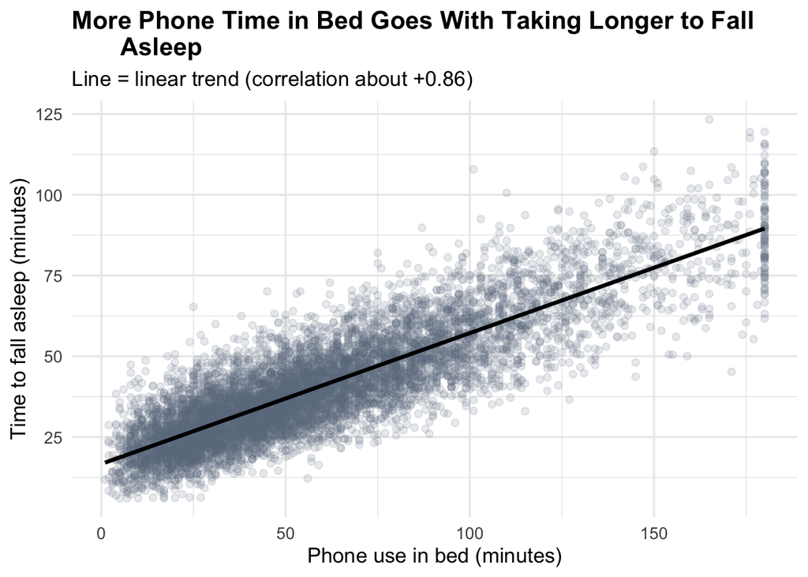

##### This scatter plot shows bedtime_phone_minutes against sleep_latency_min, with each point as one participant and a line showing the overall trend. The pattern is strong and close to a straight line: the correlation is about +0.86, and each extra hour on the phone goes with roughly 24 more minutes to fall asleep (people with 30 minutes or less take about 25 minutes, while those over two hours take about 77). This suggests that phone use before bed is closely tied to trouble falling asleep. A possible explanation is that phone use delays sleep through stimulation and light, but it could also work the other way, with people who can’t sleep picking up their phones, or a third factor like stress affecting both. Because this is a single snapshot of each person, the data can’t tell these apart. I would check whether the pattern holds across groups and whether screen brightness or the blue light filter changes it. There is also a stack of points at 180 minutes, which may mean the measure was capped there.

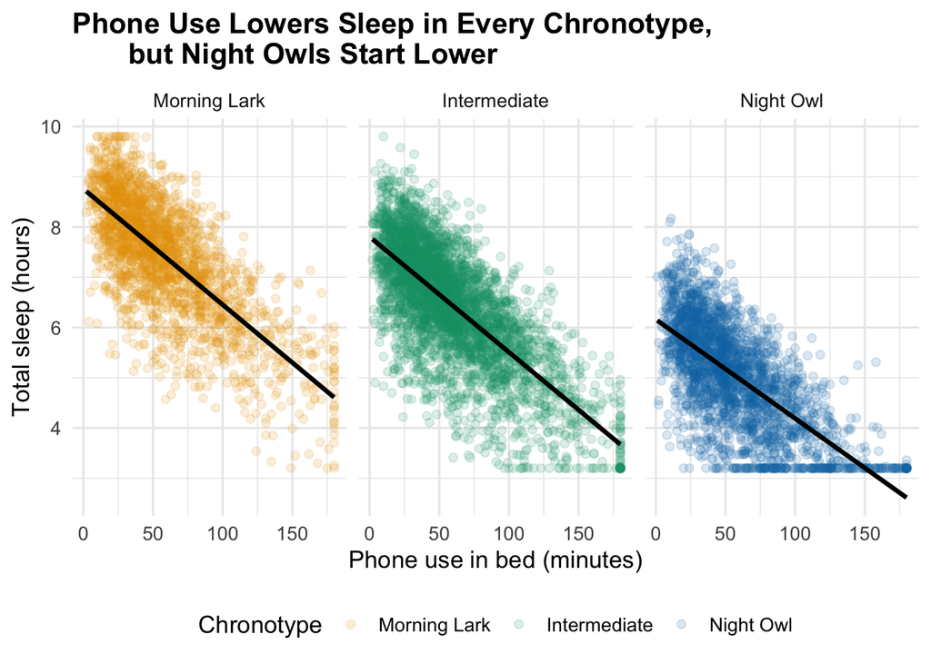

##### This chart shows bedtime_phone_minutes against total_sleep_hours, split into three panels by chronotype, which is also shown by color. In all three panels, more phone use goes with less sleep, and the three trend lines have about the same downward slope. The correlation is about −0.55 overall but about −0.67 to −0.73 within each group, because the gaps between chronotypes add noise to the overall pattern. People who use their phone 30 minutes or less sleep about 8.3 hours as Morning Larks but 5.9 as Night Owls, and those over two hours sleep about 5.3 and 3.5. This suggests that phone use and chronotype are separate influences on sleep, especially since average phone use is nearly the same across groups (about 58 to 60 minutes), so chronotype doesn’t seem to be explaining away the phone effect. One possible explanation is that bedtime routines shorten sleep in a similar way for everyone, while chronotype shifts everyone’s baseline. Next I would add occupation_type as another breakdown and check whether the slopes differ by group in a regression model.

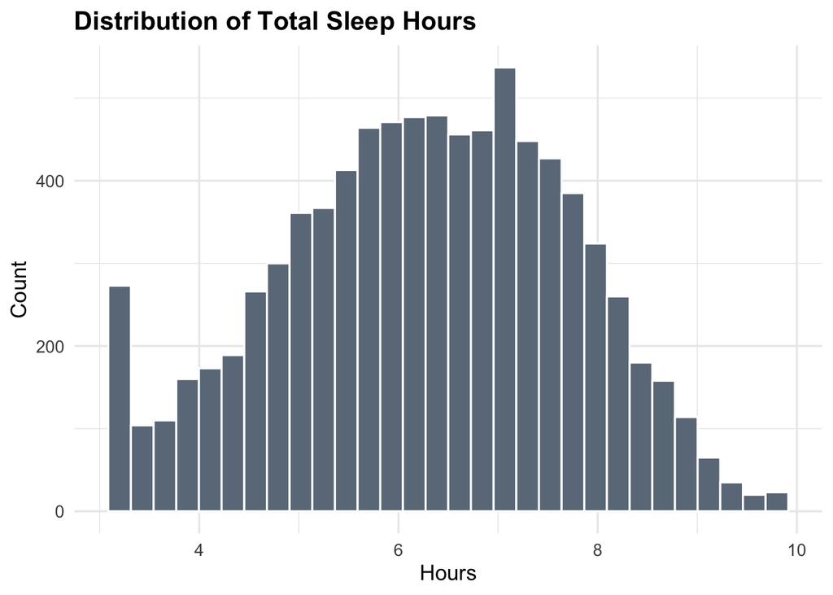

##### This histogram shows how many participants fall at each level of nightly sleep. Most people sleep between about 5 and 7.5 hours (mean and median both about 6.3), but the left side has a tall bar at the lowest value: 242 participants sleep exactly 3.2 hours, mostly Night Owls (199) and shift workers (127). This suggests 3.2 hours is a minimum in the data, so very short sleepers may be bunched together by a recording limit. It also means the distribution is slightly skewed toward low sleep, and about 42% of people sleep under 6 hours. Next I would check whether 3.2 is a cap in how the data was recorded and whether the pile-up is concentrated in certain groups.

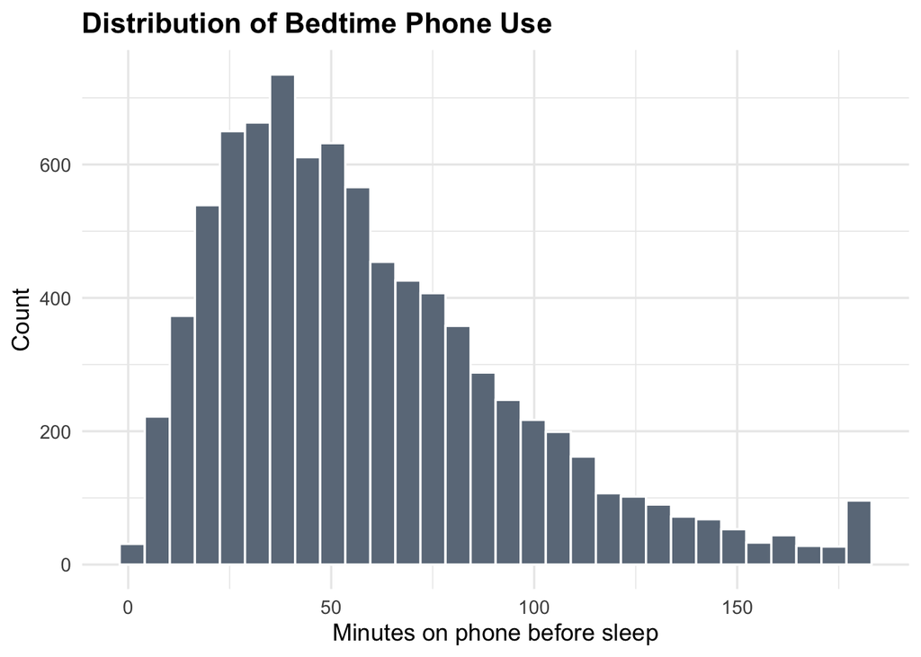

##### This histogram shows how long participants spend on their phone in bed before sleep. It is right-skewed, with most people between about 20 and 60 minutes (median about 51, mean about 59) and a long tail out to 180 minutes, where 87 people sit at exactly the maximum. This suggests that a typical participant uses their phone for under an hour, while about 7.5% use it for over two hours. The spike at 180 may mean the measure was capped, so true use for those people could be higher. I would check how this variable was recorded and whether heavy users differ from others in sleep latency and total sleep.

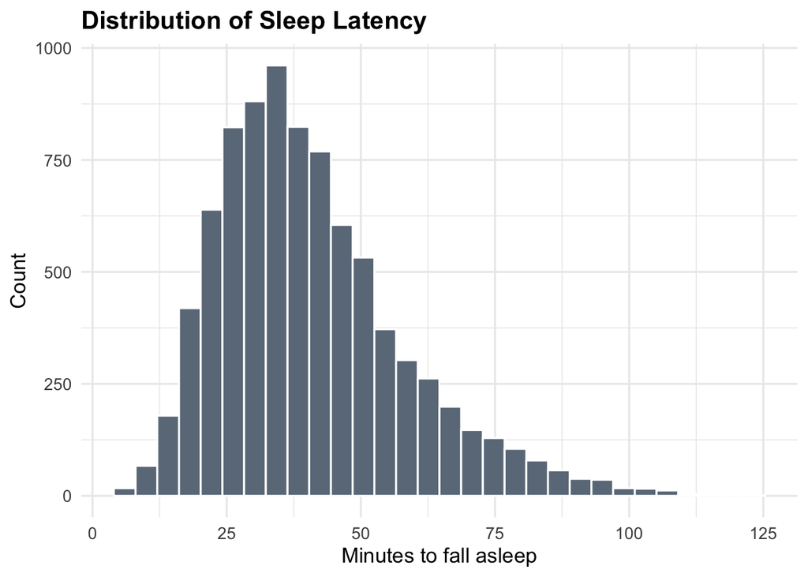

##### This histogram shows how many minutes it takes participants to fall asleep. It is right-skewed with a median of about 38 minutes, a middle 50% between about 28 and 50 minutes, and a tail up to about 123 minutes. This suggests that about 70% of participants take more than 30 minutes to fall asleep and about 14% take over an hour, which is a long time overall. One possible explanation is that bedtime phone use stretches the time to fall asleep, since latency has a strong relationship with phone minutes (about +0.86). I would check how the tail of long latencies relates to phone use and to chronotype.

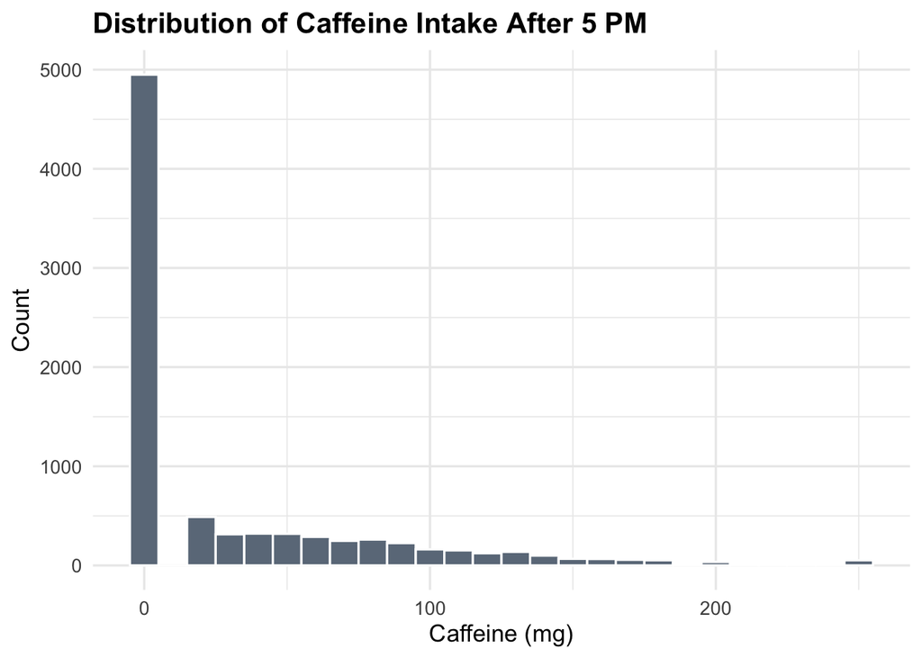

##### This histogram shows the amount of caffeine participants had after 5 PM. About 58% (4,950 people) had none, and no one has a value between 1 and 19 mg (the smallest nonzero amount is 20 mg). Among those who did consume caffeine, the median is about 67 mg, and 49 people sit at a maximum of 250 mg. This suggests that caffeine is better treated as two groups (none vs. some) than as one continuous scale, and the overall mean of about 33 mg doesn’t describe a typical person. Caffeine is related to REM sleep (about −0.42), deep sleep (about −0.34), and sleep latency (about +0.20), so I would compare consumers and non-consumers on those outcomes next.

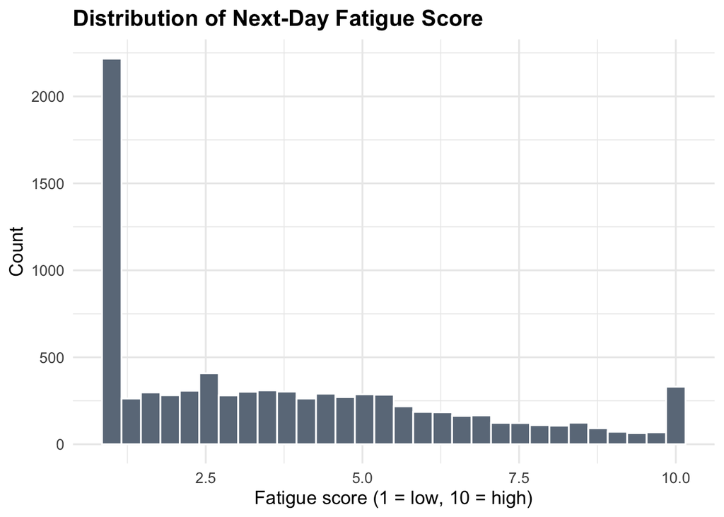

##### This histogram shows self-rated fatigue from 1 (low) to 10 (high). About 25% of participants (2,110) scored exactly 1, and 314 scored exactly 10, which suggests the scale has a floor and a ceiling that bunch up the extremes. The spike at 1 is mostly Morning Larks (about 47% of them scored 1, versus about 4% of Night Owls), and the average fatigue for the Severe Sleep Debt category is about 9.6, which matches the bump at 10. Fatigue therefore appears to track how much people sleep, and the floor means differences among well-rested people are hidden. I would check how fatigue relates to sleep hours and consider grouping the scores instead of treating them as perfectly continuous.

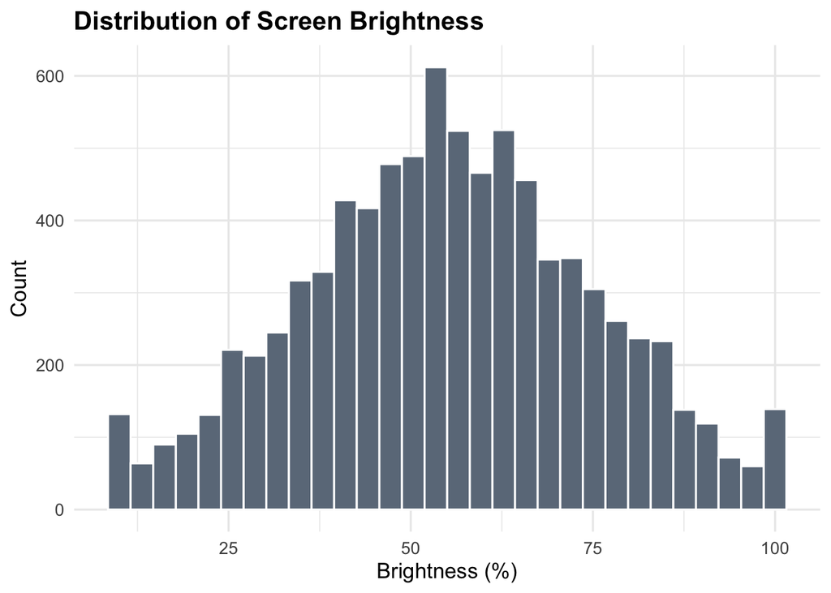

##### This histogram shows the phone screen brightness participants used at bedtime. It is bell-shaped, centered at about 55% (middle half between about 42% and 69%), with small bumps at the extremes where 122 people used 10% and 127 used 100%, which are probably the minimum and maximum settings. This suggests most people use a medium brightness, with a few at the limits. Brightness shows almost no relationship to phone minutes (about 0.00) and only a weak one to sleep latency (about +0.09), so it may matter less than I’d expect. I would check whether brightness matters more for heavy phone users or in combination with the blue light filter.

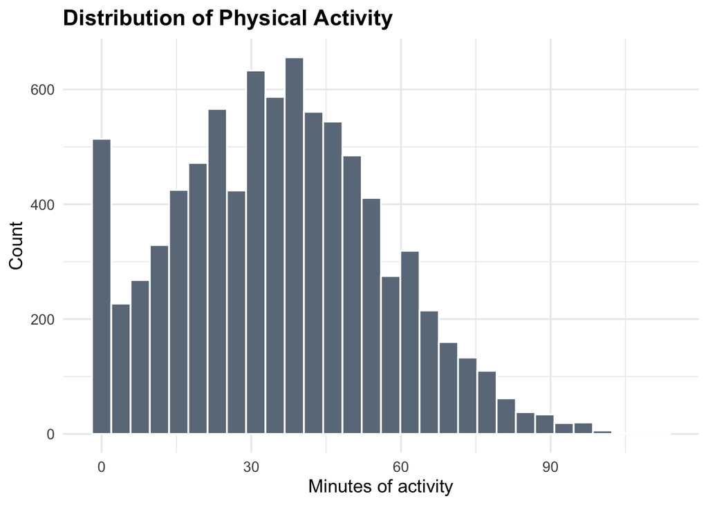

##### This histogram shows minutes of physical activity. It is roughly bell-shaped with a slight right skew, centered at about 35 minutes (middle half between 21 and 50), and about 5.5% of people (468) recorded 0 minutes. This suggests most participants get a moderate amount of activity, with a small group that is inactive and a smaller one over 90 minutes. Surprisingly, activity has essentially no correlation with total sleep (about 0.00), so it doesn’t seem to explain sleep differences here. I would check whether this changes within groups, such as by occupation or chronotype, and note that the data doesn’t say when the activity happened.

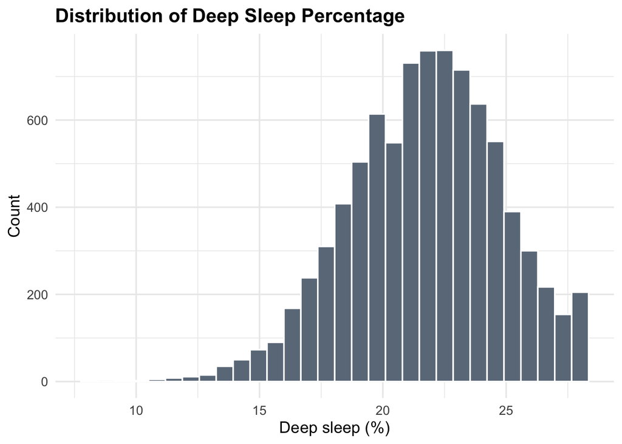

##### This histogram shows the share of sleep spent in deep sleep. It has a slight left skew, with a median of about 22% (middle half between about 20% and 24%), and a ceiling at 28%, where 160 people sit at exactly the maximum. This suggests deep sleep varies in a fairly narrow range, with a tail of people who get much less (154 under 15%). Deep sleep is related to late caffeine (about −0.34) but only weakly to total sleep hours (about +0.18). I would check whether the tail of low deep sleep is made up of caffeine consumers and whether the 28% limit is a cap.

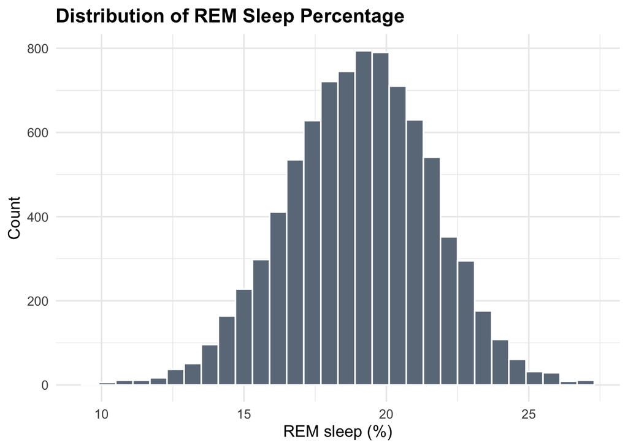

##### This histogram shows the share of sleep spent in REM sleep. It is symmetric and bell-shaped, centered at about 19% (middle half between about 17% and 21%), with values from about 10% to 27%. This suggests REM share is stable across most people, with a few at the low end. It has the strongest link to late caffeine of any sleep stage (about −0.42), but almost none to total sleep hours (about 0.03), which suggests that what you consume affects REM more than how long you sleep. I would compare REM between caffeine consumers and non-consumers and check whether the link holds within each chronotype.

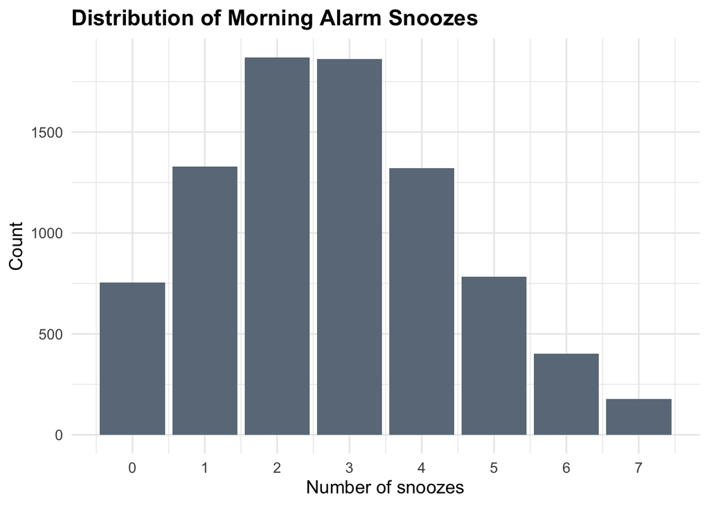

##### This bar chart shows how many times participants hit snooze. The most common values are 2 and 3 snoozes (about 1,870 and 1,860 people), about 9% never snooze, and about 16% snooze 5 or more times, so the shape is slightly right-skewed with a mean of about 2.8. Snoozing rises as sleep falls: Morning Larks average about 2.0 snoozes, Night Owls about 3.7, and the Severe Sleep Debt group about 5.9. One explanation is that tired people snooze more, though forced early wake times could also play a part. I would check how snoozes relate to fatigue (about +0.88) and treat snoozes as a result of poor sleep, not a cause.

| chronotype | n | percent |
| --- | --- | --- |
| Morning Lark | 2165 | 25.5 |
| Intermediate | 3880 | 45.6 |
| Night Owl | 2455 | 28.9 |

##### This table shows how many participants are in each group: Morning Lark 2,165 (25.5%), Intermediate 3,880 (45.6%), and Night Owl 2,455 (28.9%). Intermediate is the largest group, but all three are big enough to compare. I would check that group comparisons weigh the groups fairly, since Intermediate has almost twice as many participants as Morning Lark.

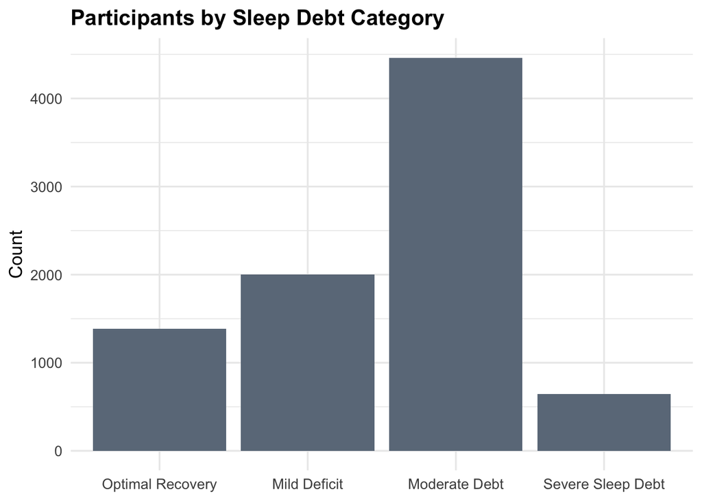

##### This bar chart shows how many participants fall in each sleep debt category: Optimal Recovery 1,387 (16.3%), Mild Deficit 2,004 (23.6%), Moderate Debt 4,462 (52.5%), and Severe Sleep Debt 647 (7.6%). This suggests that about 84% of participants are below optimal, and most are in the middle category. Chronotype is related to this pattern, since about 81% of Night Owls are in Moderate Debt and almost none (0.2%) are Optimal, compared with 42% of Morning Larks. The category is closely tied to sleep hours (Optimal starts around 7.75 hours, Mild around 6.75), although Moderate and Severe overlap in hours, so the exact rule is unclear. I would check how the category is defined and avoid using it to predict sleep hours.

```
##                  user_id                      age                   gender
##                        0                        0                        0
##          occupation_type               chronotype    bedtime_phone_minutes
##                        0                        0                        0
##      primary_bedtime_app    screen_brightness_pct blue_light_filter_active
##                        0                        0                        0
##     caffeine_post_5pm_mg    physical_activity_min        sleep_latency_min
##                        0                        0                        0
##        total_sleep_hours           deep_sleep_pct            rem_sleep_pct
##                        0                        0                        0
##    morning_alarm_snoozes   next_day_fatigue_score      sleep_debt_category
##                        0                        0                        0
```

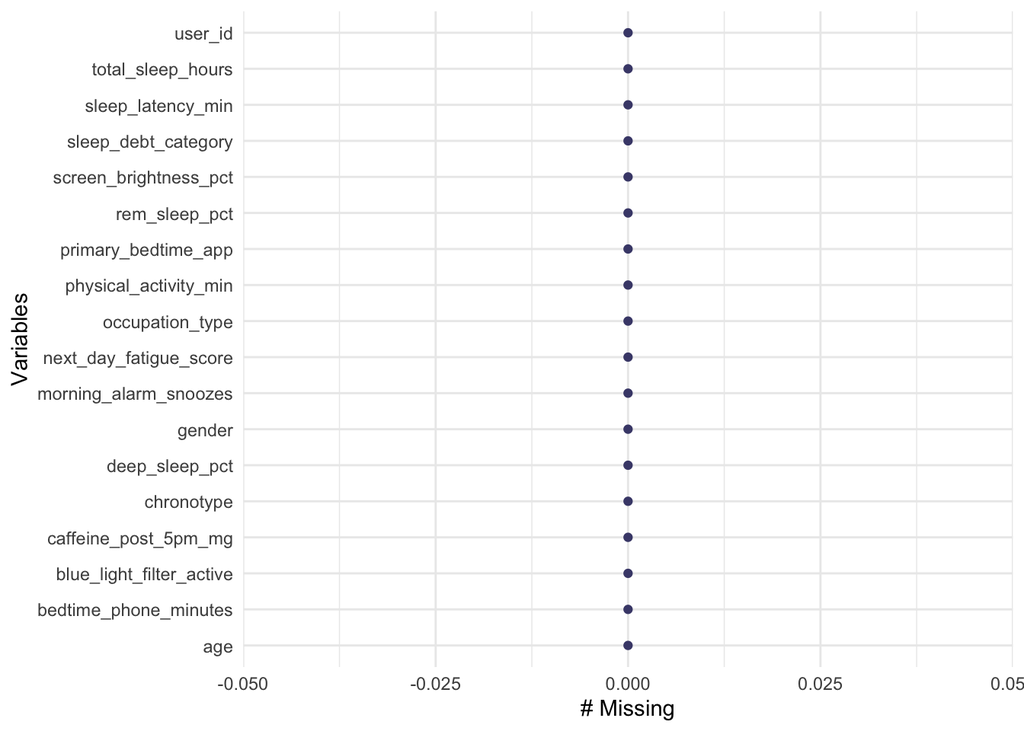

```
## [1] 0
```

```
## [1] 0
```

```
## $gender
## [1] "Female"     "Male"       "Non-Binary"
##
## $occupation_type
## [1] "Corporate 9-to-5"          "Freelance / Creative"
## [3] "Healthcare / Shift Worker" "Remote Tech"
## [5] "Student"
##
## $chronotype
## [1] "Morning Lark" "Intermediate" "Night Owl"
##
## $primary_bedtime_app
## [1] "Instagram / Reddit"       "Messaging / Chat"
## [3] "News / Reading"           "Streaming (Netflix/Hulu)"
## [5] "TikTok / Reels"           "YouTube"
##
## $blue_light_filter_active
## [1] "Off" "On"
##
## $sleep_debt_category
## [1] "Optimal Recovery"  "Mild Deficit"      "Moderate Debt"
## [4] "Severe Sleep Debt"
```

```
## # A tibble: 1 × 4
##   min_age max_age min_sleep max_sleep
##     <dbl>   <dbl>     <dbl>     <dbl>
## 1      18      65       3.2       9.8
```

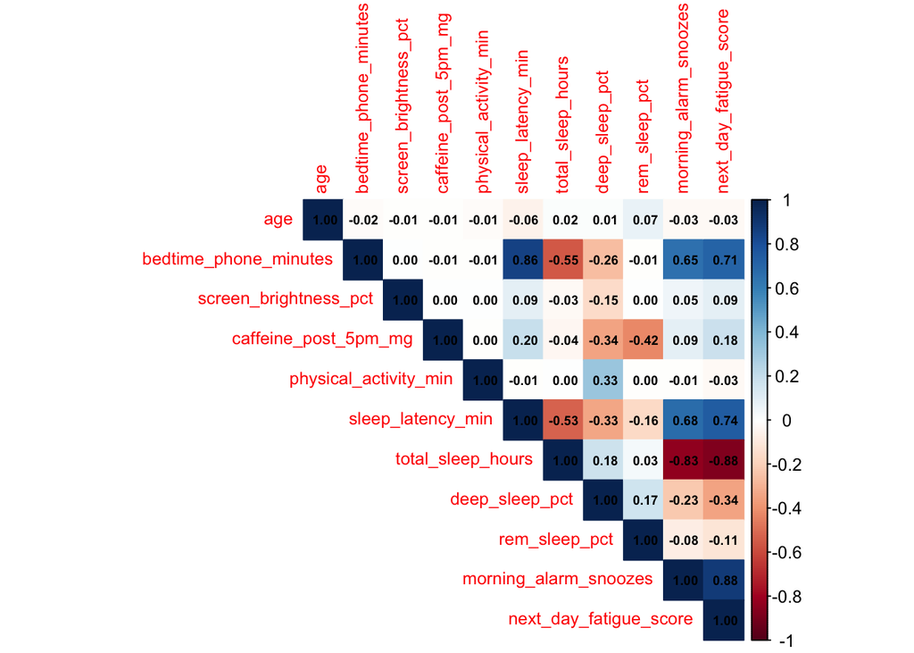

##### There are no null or NA cells in any of the 18 columns across all 8,500 rows, and I didn’t need to remove any observations because there were no duplicate rows or IDs and every value fell within a plausible range. The categories are all spelled consistently, so nothing needed correcting, though a few variables are hard to interpret without documentation, such as how sleep_debt_category is defined, what the fatigue score measures, and whether each row is a single night or an average. Several features are strongly correlated, including phone time before bed with sleep latency (about +0.86), total sleep hours with next-day fatigue (about −0.88), and alarm snoozes with fatigue (about +0.88), though correlation doesn’t show that one causes the other.

## Discussion

Overall, this dataset gives a clear and fairly complete picture of how bedtime phone habits relate to sleep. It has 8,500 participants and 18 features, with no missing values, no duplicates, and no spelling problems. In general, people in this sample are not getting much sleep: the average is about 6.3 hours, and roughly 42% sleep fewer than 6 hours. Several of the most interesting findings involve phone use. People spend about 59 minutes on their phone in bed on average, but the distribution is right-skewed, with some using their phones for up to 3 hours. Bedtime phone minutes are strongly correlated with sleep latency (about +0.86), meaning more phone time goes with taking longer to fall asleep, and moderately correlated with total sleep hours (about −0.55). Other patterns stood out as well. Night Owls average about 5.0 hours of sleep compared with about 7.4 for Morning Larks, and shift workers average about 5.0 hours while the other occupation groups sit near 6.4. Also, the type of app used at bedtime seemed to make almost no difference in phone time or sleep hours, and the blue light filter showed only a small difference in sleep latency (about 39.6 vs. 41.6 minutes).

I also have some concerns about the data. The file has no documentation, so I’m unsure how some variables were measured or defined. For example, I don’t know whether the sleep and fatigue values are self-reported or tracked by a device, whether each row is a single night or an average, or how sleep_debt_category was assigned. It appears to be closely tied to total sleep hours, which means it shouldn’t be treated as an independent variable. Several variables, such as alarm snoozes, fatigue, and sleep latency, are strongly correlated with each other and look more like effects of poor sleep than causes, so I’ll need to be careful about which ones I treat as predictors. A data set this clean is unusual for real survey data, so I’m also uncertain how it was collected and whether it represents a wider population. The sample also skews young (about 45% are 30 or younger) and includes only about 250 Non-Binary participants, which limits how far some comparisons can go. Finally, since these are correlations, I can’t conclude that phone use causes worse sleep.

For next steps, I plan to compare sleep outcomes across groups, especially chronotype, since they showed the largest differences and may confound the effect of phone use. I also want to look at scatter plots and group comparisons of bedtime phone minutes against sleep latency and total sleep hours, and then check whether that relationship holds within each chronotype, to see whether phone use matters on its own or mostly reflects who the person is. These steps fit my main question of how screen time before bed affects sleep, and they would show which relationships are worth modeling later in the semester.

## Overall Take

Through this project, I’ve learned that my data shows a clear and consistent connection between bedtime phone use and sleep. The more time participants spend on their phone in bed, the longer it takes them to fall asleep (about 24 more minutes per extra hour, with a correlation near +0.86) and the less they sleep overall, and this pattern holds in every chronotype group. I also learned that people in this sample are generally short on sleep, averaging about 6.3 hours, and that the biggest differences in sleep come from who the person is, not from what they do at bedtime. Night Owls average about 5.0 hours and Morning Larks about 7.4, and shift workers average about 5.0 compared with about 6.4 for other occupations.

Some results surprised me. I expected chronotype to explain away much of the phone effect, but Night Owls use their phones about as much as everyone else, and the phone relationship stays equally strong within each group. I was also surprised that the type of app people use before bed barely affected phone time or sleep, and that the blue light filter made only a small difference in how long it takes to fall asleep (about 39.6 vs. 41.6 minutes). The data is also remarkably clean, with no missing values, which makes me wonder how it was collected, and since I can’t tell whether it’s measured or self-reported, I’m careful not to claim that phone use causes poor sleep.

I still want to answer a few questions. Do chronotype and occupation overlap, such as Night Owls being concentrated among shift workers? Does the phone effect stay the same after accounting for chronotype, occupation, caffeine, and age together? And do brightness or the blue light filter change how harmful phone time is? For my draft, I plan to build a regression model to test these together, add a visual comparing occupation groups, and tighten my data cleanliness notes. I’ll also add a clear statement of what the data can and cannot show.